# Communication Coding

Matt Blanchard

25/09/2019

Need to decide whether to keep drivers with issues in the dataset

# Comparison of the mean number of communication events coded by each driver

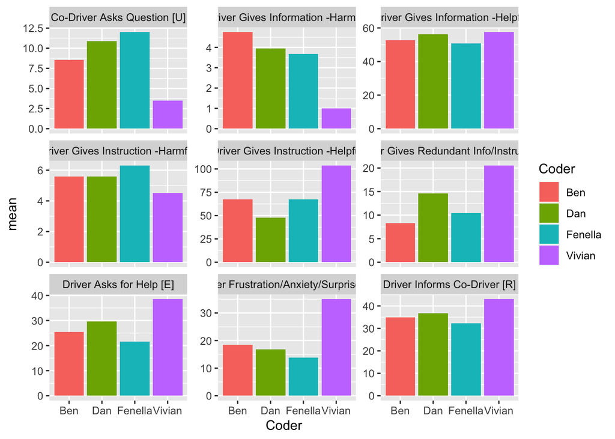

| Coder | n |
| --- | --- |
| All | 1 |
| Ben | 13 |
| Dan | 21 |
| Fenella | 17 |
| Vivian | 2 |

# Descriptives and distributions for communication variables overall

| var | mean | sd |
| --- | --- | --- |
| co_info_harm_overall | 2.870370 | 3.387247 |
| co_info_help_overall | 52.629630 | 27.007544 |
| co_instruct_harm_overall | 5.722222 | 5.052243 |
| co_instruct_help_overall | 63.296296 | 46.166487 |
| co_question_overall | 10.148148 | 8.841172 |
| co_redundant_overall | 11.740741 | 8.780736 |
| co_total_harm_overall | 8.592593 | 7.196746 |
| co_total_help_overall | 115.925926 | 62.224139 |
| co_total_overall | 146.407407 | 73.183543 |
| drive_frust_overall | 17.574074 | 18.481609 |
| drive_informs_overall | 34.648148 | 25.667068 |
| drive_question_overall | 25.722222 | 16.519190 |
| drive_total_overall | 60.370370 | 35.455684 |
| leadership | 13.250000 | 3.516289 |
| leadership_co_driver | 6.944444 | 1.548168 |
| leadership_driver | 6.305556 | 2.315407 |
| overall | 6.527778 | 2.184178 |
| sit.awareness | 13.194444 | 1.939358 |
| sit.awareness_co_driver | 6.222222 | 1.333333 |
| sit.awareness_driver | 6.972222 | 1.275844 |
| teamwork | 22.277778 | 3.558580 |

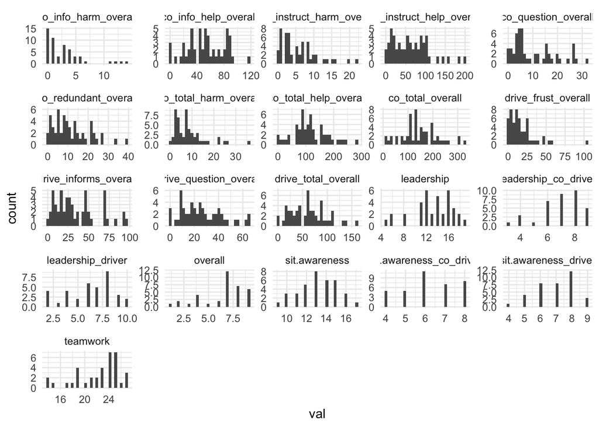

# Reliability for each communication variable overall

```
## [[1]]
## [1] "co_info_help = 0.84"
##
## [[2]]
## [1] "co_info_harm = 0.73"
##
## [[3]]
## [1] "co_instruct_help = 0.9"
##
## [[4]]
## [1] "co_instruct_harm = 0.52"
##
## [[5]]
## [1] "co_total_help = 0.88"
##
## [[6]]
## [1] "co_total_harm = 0.64"
##
## [[7]]
## [1] "co_redundant = 0.73"
##
## [[8]]
## [1] "co_question = 0.8"
##
## [[9]]
## [1] "co_total = 0.87"
##
## [[10]]
## [1] "drive_question = 0.8"
##
## [[11]]
## [1] "drive_informs = 0.85"
##
## [[12]]
## [1] "drive_frust = 0.89"
##
## [[13]]
## [1] "drive_total = 0.83"
```

# Relationships between communication variables and time_talking variables overall

Validation check: do the communication coding varaibles relate to the time talking variables

| rowname | drive_total_overall | co_total_overall |
| --- | --- | --- |
| time_talking_overall | 0.69 | 0.73 |
| time_talking_events_overall | 0.70 | 0.71 |
| time_talking_none_overall | 0.65 | 0.70 |
| time_talking_overall_drone | 0.56 | 0.57 |
| time_talking_events_overall_drone | 0.50 | 0.54 |
| time_talking_none_overall_drone | 0.55 | 0.53 |

# Relationship between communication variables and time_talking variables per lap

| rowname | co_total_1 | co_total_2 | co_total_3 | co_total_4 | co_total_5 | drive_total_1 | drive_total_2 | drive_total_3 | drive_total_4 | drive_total_5 |
| --- | --- | --- | --- | --- | --- | --- | --- | --- | --- | --- |
| time_talking_1 | 0.62 | 0.59 | 0.52 | 0.45 | 0.55 | 0.59 | 0.43 | 0.44 | NA | 0.45 |
| time_talking_2 | 0.35 | 0.60 | 0.42 | 0.41 | 0.37 | NA | 0.48 | 0.35 | NA | 0.28 |
| time_talking_3 | 0.32 | 0.41 | 0.57 | 0.39 | 0.34 | 0.30 | 0.40 | 0.63 | NA | 0.36 |
| time_talking_4 | 0.33 | 0.37 | 0.49 | 0.70 | 0.46 | NA | 0.40 | 0.50 | 0.65 | 0.46 |
| time_talking_5 | 0.58 | 0.63 | 0.59 | 0.30 | 0.48 | 0.65 | 0.59 | 0.53 | 0.29 | 0.68 |
| time_talking_events_1 | 0.64 | 0.37 | 0.41 | 0.30 | 0.48 | 0.59 | NA | 0.27 | NA | 0.38 |
| time_talking_events_2 | 0.36 | 0.58 | 0.51 | 0.55 | 0.46 | 0.34 | 0.53 | 0.51 | 0.34 | 0.35 |
| time_talking_events_3 | NA | NA | 0.56 | NA | NA | 0.38 | 0.30 | 0.67 | NA | 0.48 |
| time_talking_events_4 | NA | 0.33 | 0.31 | 0.72 | 0.44 | NA | 0.41 | 0.45 | 0.74 | 0.44 |
| time_talking_events_5 | 0.51 | 0.40 | 0.45 | NA | 0.51 | 0.60 | 0.36 | 0.41 | NA | 0.61 |
| time_talking_none_1 | 0.53 | 0.60 | 0.50 | 0.45 | 0.50 | 0.51 | 0.47 | 0.46 | NA | 0.42 |
| time_talking_none_2 | 0.30 | 0.55 | 0.32 | 0.30 | 0.27 | NA | 0.39 | NA | NA | NA |
| time_talking_none_3 | 0.31 | 0.41 | 0.53 | 0.39 | 0.34 | NA | 0.38 | 0.58 | NA | 0.31 |
| time_talking_none_4 | 0.37 | 0.35 | 0.53 | 0.63 | 0.43 | NA | 0.36 | 0.48 | 0.54 | 0.42 |
| time_talking_none_5 | 0.53 | 0.67 | 0.59 | 0.29 | 0.38 | 0.59 | 0.65 | 0.52 | 0.31 | 0.61 |
| time_talking_1_drone | 0.70 | 0.59 | 0.55 | 0.43 | 0.62 | 0.58 | 0.33 | 0.32 | NA | 0.34 |
| time_talking_2_drone | NA | 0.48 | 0.37 | NA | NA | 0.34 | 0.49 | 0.41 | NA | NA |
| time_talking_3_drone | NA | NA | 0.40 | NA | NA | NA | NA | 0.49 | NA | NA |
| time_talking_4_drone | NA | NA | NA | 0.69 | 0.37 | NA | NA | 0.29 | 0.67 | NA |
| time_talking_5_drone | NA | NA | NA | NA | 0.41 | NA | NA | NA | NA | 0.45 |
| time_talking_events_1_drone | 0.59 | 0.40 | 0.36 | 0.30 | 0.56 | 0.46 | NA | NA | NA | NA |
| time_talking_events_2_drone | NA | 0.61 | 0.35 | NA | NA | 0.33 | 0.63 | 0.40 | NA | 0.32 |
| time_talking_events_3_drone | NA | NA | 0.30 | NA | NA | NA | NA | NA | NA | NA |
| time_talking_events_4_drone | NA | NA | NA | 0.64 | 0.35 | NA | NA | NA | 0.58 | NA |
| time_talking_events_5_drone | NA | NA | NA | NA | 0.41 | NA | NA | NA | NA | 0.41 |
| time_talking_none_1_drone | 0.66 | 0.62 | 0.58 | 0.44 | 0.58 | 0.56 | 0.39 | 0.37 | 0.28 | 0.37 |
| time_talking_none_2_drone | NA | 0.29 | 0.31 | NA | NA | 0.27 | 0.30 | 0.33 | NA | NA |
| time_talking_none_3_drone | NA | NA | 0.37 | NA | 0.27 | NA | NA | 0.49 | NA | NA |
| time_talking_none_4_drone | NA | NA | NA | 0.68 | 0.36 | NA | NA | 0.31 | 0.68 | 0.30 |
| time_talking_none_5_drone | NA | NA | NA | NA | 0.35 | NA | NA | NA | NA | 0.41 |

# Relationships between communication variables

Is there a multicollinearity issue? All correlations below .5 are suppressed

| rowname | co_info_help_overall | co_info_harm_overall | co_instruct_help_overall | co_instruct_harm_overall | co_total_help_overall | co_total_harm_overall | co_redundant_overall | co_question_overall | co_total_overall | drive_question_overall | drive_informs_overall | drive_frust_overall | drive_total_overall | leadership | overall | sit.awareness | teamwork | leadership_co_driver | leadership_driver | sit.awareness_co_driver | sit.awareness_driver |
| --- | --- | --- | --- | --- | --- | --- | --- | --- | --- | --- | --- | --- | --- | --- | --- | --- | --- | --- | --- | --- | --- |
| co_info_help_overall | NA | NA | NA | NA | 0.7348632 | NA | NA | NA | 0.7068895 | 0.6290585 | 0.5165228 | NA | 0.6670063 | 0.6794062 | 0.5276852 | NA | NA | 0.6671893 | 0.5856710 | NA | NA |
| co_info_harm_overall | NA | NA | NA | NA | NA | 0.7741148 | NA | NA | NA | NA | NA | NA | NA | NA | NA | NA | NA | NA | NA | NA | NA |
| co_instruct_help_overall | NA | NA | NA | NA | 0.9179232 | NA | NA | NA | 0.9043111 | NA | NA | NA | 0.5165084 | 0.5008824 | NA | NA | NA | 0.6308033 | NA | NA | NA |
| co_instruct_harm_overall | NA | NA | NA | NA | NA | 0.9054647 | NA | NA | 0.5270957 | NA | NA | NA | NA | NA | NA | NA | NA | NA | NA | NA | NA |
| co_total_help_overall | 0.7348632 | NA | 0.9179232 | NA | NA | NA | NA | 0.5295994 | 0.9777590 | 0.5791827 | 0.5565189 | NA | 0.6727225 | 0.6465443 | NA | NA | NA | 0.7345477 | NA | NA | NA |
| co_total_harm_overall | NA | 0.7741148 | NA | 0.9054647 | NA | NA | NA | NA | NA | NA | NA | NA | NA | NA | NA | NA | NA | NA | NA | NA | NA |
| co_redundant_overall | NA | NA | NA | NA | NA | NA | NA | NA | NA | NA | NA | NA | NA | NA | NA | NA | NA | NA | NA | NA | NA |
| co_question_overall | NA | NA | NA | NA | 0.5295994 | NA | NA | NA | 0.6231900 | NA | 0.7236819 | NA | 0.6676962 | NA | NA | NA | NA | NA | NA | NA | NA |
| co_total_overall | 0.7068895 | NA | 0.9043111 | 0.5270957 | 0.9777590 | NA | NA | 0.6231900 | NA | 0.5758565 | 0.6166279 | NA | 0.7146869 | 0.6580194 | 0.5206357 | NA | NA | 0.7291031 | 0.5117940 | NA | NA |
| drive_question_overall | 0.6290585 | NA | NA | NA | 0.5791827 | NA | NA | NA | 0.5758565 | NA | NA | NA | 0.7437186 | 0.6531454 | NA | NA | NA | 0.6033299 | 0.5884889 | NA | NA |
| drive_informs_overall | 0.5165228 | NA | NA | NA | 0.5565189 | NA | NA | 0.7236819 | 0.6166279 | NA | NA | NA | 0.9027153 | 0.6994511 | 0.5905276 | NA | 0.5024575 | 0.5793848 | 0.6748215 | NA | NA |
| drive_frust_overall | NA | NA | NA | NA | NA | NA | NA | NA | NA | NA | NA | NA | NA | NA | NA | NA | NA | NA | NA | NA | NA |
| drive_total_overall | 0.6670063 | NA | 0.5165084 | NA | 0.6727225 | NA | NA | 0.6676962 | 0.7146869 | 0.7437186 | 0.9027153 | NA | NA | 0.8391868 | 0.6663953 | NA | 0.5963150 | 0.7262585 | 0.7888256 | NA | NA |
| leadership | 0.6794062 | NA | 0.5008824 | NA | 0.6465443 | NA | NA | NA | 0.6580194 | 0.6531454 | 0.6994511 | NA | 0.8391868 | NA | 0.8565624 | NA | 0.6770105 | 0.8633664 | 0.9413687 | NA | NA |
| overall | 0.5276852 | NA | NA | NA | NA | NA | NA | NA | 0.5206357 | NA | 0.5905276 | NA | 0.6663953 | 0.8565624 | NA | NA | 0.8003314 | 0.7102187 | 0.8259378 | 0.5276039 | NA |
| sit.awareness | NA | NA | NA | NA | NA | NA | NA | NA | NA | NA | NA | NA | NA | NA | NA | NA | NA | NA | NA | 0.7562638 | 0.7297183 |
| teamwork | NA | NA | NA | NA | NA | NA | NA | NA | NA | NA | 0.5024575 | NA | 0.5963150 | 0.6770105 | 0.8003314 | NA | NA | 0.5266726 | 0.6759875 | NA | NA |
| leadership_co_driver | 0.6671893 | NA | 0.6308033 | NA | 0.7345477 | NA | NA | NA | 0.7291031 | 0.6033299 | 0.5793848 | NA | 0.7262585 | 0.8633664 | 0.7102187 | NA | 0.5266726 | NA | 0.6425120 | 0.5736425 | NA |
| leadership_driver | 0.5856710 | NA | NA | NA | NA | NA | NA | NA | 0.5117940 | 0.5884889 | 0.6748215 | NA | 0.7888256 | 0.9413687 | 0.8259378 | NA | 0.6759875 | 0.6425120 | NA | NA | NA |
| sit.awareness_co_driver | NA | NA | NA | NA | NA | NA | NA | NA | NA | NA | NA | NA | NA | NA | 0.5276039 | 0.7562638 | NA | 0.5736425 | NA | NA | NA |
| sit.awareness_driver | NA | NA | NA | NA | NA | NA | NA | NA | NA | NA | NA | NA | NA | NA | NA | 0.7297183 | NA | NA | NA | NA | NA |

It looks like there is a multicollinearity issue. Need to reduce comms variables to a smaller number using factor analysis.

# Conduct EFA to extract comms factors

Reduce variables to smaller number of factors and correlate with each other. It looks like 3 components can be extracted from the comms variables.

## Correlations between original comms variables

|  | co_info_help_overall | co_info_harm_overall | co_instruct_help_overall | co_instruct_harm_overall | co_redundant_overall | co_question_overall | drive_question_overall | drive_informs_overall | drive_frust_overall |
| --- | --- | --- | --- | --- | --- | --- | --- | --- | --- |
| co_info_help_overall | 1.00 | 0.31 | 0.41 | 0.13 | 0.11 | 0.38 | 0.63 | 0.52 | 0.14 |
| co_info_harm_overall | 0.31 | 1.00 | 0.03 | 0.43 | 0.36 | 0.03 | 0.23 | 0.17 | 0.39 |
| co_instruct_help_overall | 0.41 | 0.03 | 1.00 | 0.48 | 0.25 | 0.49 | 0.41 | 0.45 | 0.30 |
| co_instruct_harm_overall | 0.13 | 0.43 | 0.48 | 1.00 | 0.30 | 0.45 | 0.15 | 0.35 | 0.30 |
| co_redundant_overall | 0.11 | 0.36 | 0.25 | 0.30 | 1.00 | 0.16 | 0.21 | 0.20 | 0.33 |
| co_question_overall | 0.38 | 0.03 | 0.49 | 0.45 | 0.16 | 1.00 | 0.31 | 0.72 | 0.11 |
| drive_question_overall | 0.63 | 0.23 | 0.41 | 0.15 | 0.21 | 0.31 | 1.00 | 0.38 | 0.28 |
| drive_informs_overall | 0.52 | 0.17 | 0.45 | 0.35 | 0.20 | 0.72 | 0.38 | 1.00 | 0.26 |
| drive_frust_overall | 0.14 | 0.39 | 0.30 | 0.30 | 0.33 | 0.11 | 0.28 | 0.26 | 1.00 |

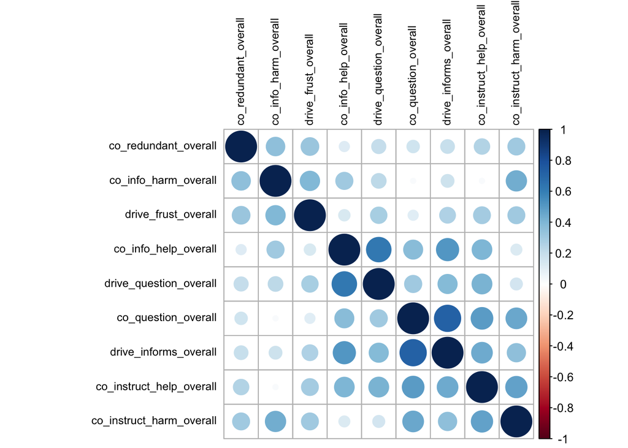

## KMO and Bartlett’s test of Spherecity

```
## Kaiser-Meyer-Olkin factor adequacy
## Call: KMO(r = cor_pca)
## Overall MSA =  0.65
## MSA for each item =
##     co_info_help_overall     co_info_harm_overall co_instruct_help_overall
##                     0.61                     0.44                     0.67
## co_instruct_harm_overall     co_redundant_overall      co_question_overall
##                     0.58                     0.78                     0.69
##   drive_question_overall    drive_informs_overall      drive_frust_overall
##                     0.77                     0.74                     0.67
```

```
## [1] "Bartletts test of spherecity"
```

```
##      chisq      p.value df
## 1 176.0047 2.388931e-20 36
```

## Communalities

|  | communalities |
| --- | --- |
| co_info_help_overall | 0.8234512 |
| co_info_harm_overall | 0.7024189 |
| co_instruct_help_overall | 0.5942012 |
| co_instruct_harm_overall | 0.7364314 |
| co_redundant_overall | 0.4878589 |
| co_question_overall | 0.8118682 |
| drive_question_overall | 0.7569450 |
| drive_informs_overall | 0.7048236 |
| drive_frust_overall | 0.5204578 |

## Variance explained by the extracted components

| component | eigen | prop_var | cum_var | rotation_SS_load |
| --- | --- | --- | --- | --- |
| 1 | 3.54 | 0.27 | 0.27 | 2.42 |
| 2 | 1.47 | 0.22 | 0.49 | 1.98 |
| 3 | 1.12 | 0.19 | 0.68 | 1.74 |
| 4 | 0.78 |  |  |  |
| 5 | 0.68 |  |  |  |
| 6 | 0.62 |  |  |  |
| 7 | 0.37 |  |  |  |
| 8 | 0.22 |  |  |  |
| 9 | 0.19 |  |  |  |

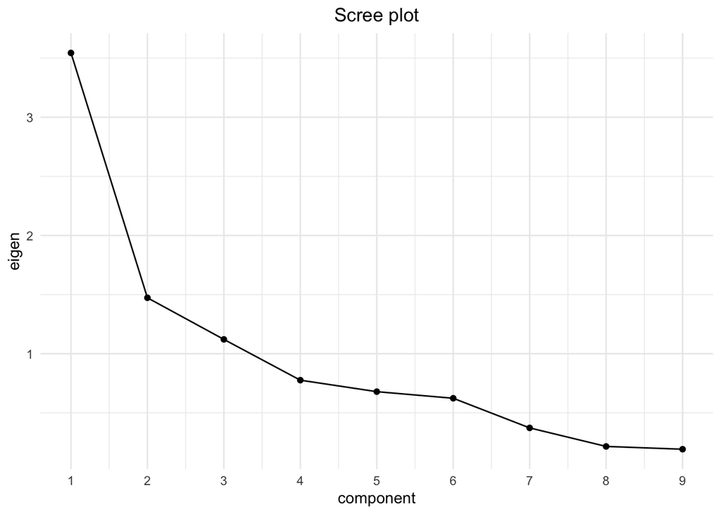

## Pattern matrix

| var | PC1 | PC2 | PC3 |
| --- | --- | --- | --- |
| co_question_overall | 0.95 |  |  |
| drive_informs_overall | 0.73 |  |  |
| co_instruct_help_overall | 0.71 |  |  |
| co_instruct_harm_overall | 0.62 | 0.46 | -0.33 |
| co_info_harm_overall |  | 0.87 |  |
| drive_frust_overall |  | 0.71 |  |
| co_redundant_overall |  | 0.68 |  |
| co_info_help_overall |  |  | 0.85 |
| drive_question_overall |  |  | 0.81 |

## Component correlations matrix

```
##              inconsistent terrible helpful
## inconsistent         1.00     0.38    0.33
## terrible             0.38     1.00    0.17
## helpful              0.33     0.17    1.00
```

## Check that component scores extracted using SPSS and R are the same

```
##               component      r
## 1 inconsistent_codriver 0.9998
## 2     terrible_codriver 0.9996
## 3      helpful_exchange 0.9997
```

# Descriptives statistics

## Driver

| var | mean | sd |
| --- | --- | --- |
| agreeableness | 3.9814815 | 0.6347854 |
| bias | 3.1247563 | 19.6581667 |
| confidence | 58.3732943 | 19.5355017 |
| congruent_errors | 0.9259259 | 1.5522577 |
| congruent_time | 448.1233170 | 50.4431149 |
| conscientiousness | 3.1018519 | 0.7578497 |
| discrimination | 28.8450836 | 19.6573836 |
| driving_years | 3.2759259 | 4.7506975 |
| extraversion | 3.1805556 | 0.7339745 |
| gaming_time | 1.2611111 | 1.0539981 |
| gf_accuracy | 55.2485380 | 21.9247379 |
| incongruent_errors | 1.6296296 | 1.7835337 |
| incongruent_time | 514.9220618 | 62.9894769 |
| inhibitory_cost | 66.7987448 | 31.0899142 |
| intellect | 3.5601852 | 0.6459876 |
| neuroticism | 2.8194444 | 0.7482947 |
| repeat_errors | 1.7777778 | 1.6559403 |
| repeat_time | 930.6465795 | 241.5838445 |
| resilience | 3.6416667 | 0.3331304 |
| switch_cost | 103.8064106 | 116.5849629 |
| switch_errors | 2.1111111 | 1.9968529 |
| switch_time | 1034.4529901 | 289.0403185 |
| wm_accuracy | 40.8641975 | 19.4277157 |

## Drone

| var | mean | sd |
| --- | --- | --- |
| agreeableness | 3.8564815 | 0.6287188 |
| bias | 2.9634990 | 21.5214843 |
| confidence | 61.8913743 | 18.5099683 |
| congruent_errors | 0.9433962 | 1.1996008 |
| congruent_time | 475.2389926 | 48.3116002 |
| conscientiousness | 3.3750000 | 0.7231841 |
| discrimination | 25.7355718 | 19.2923756 |
| driving_years | 2.1583333 | 5.0555662 |
| extraversion | 3.1712963 | 0.7001079 |
| gaming_time | 0.9851852 | 0.9615548 |
| gf_accuracy | 58.9278752 | 21.9974704 |
| incongruent_errors | 1.4528302 | 1.8663625 |
| incongruent_time | 549.7244047 | 50.8202251 |
| inhibitory_cost | 74.4854121 | 28.6777153 |
| intellect | 3.6435185 | 0.6878354 |
| neuroticism | 2.7731481 | 0.7223986 |
| repeat_errors | 1.5370370 | 1.8193194 |
| repeat_time | 910.7848427 | 248.6520445 |
| resilience | 3.5858333 | 0.3805027 |
| switch_cost | 146.7856383 | 166.8224329 |
| switch_errors | 1.9629630 | 2.2816988 |
| switch_time | 1057.5704810 | 322.0664585 |
| wm_accuracy | 45.6790123 | 17.4906939 |

# Driver: relationship between communication factors and psych variables

| rowname | age_driver | sex_driver | mean_age | prop_female | driving_years | gaming_time | congruent_errors | congruent_time | incongruent_errors | incongruent_time | inhibitory_cost | repeat_errors | repeat_time | switch_errors | switch_time | switch_cost | wm_accuracy | resilience | gf_accuracy | confidence | bias | discrimination | agreeableness | conscientiousness | extraversion | intellect | neuroticism |
| --- | --- | --- | --- | --- | --- | --- | --- | --- | --- | --- | --- | --- | --- | --- | --- | --- | --- | --- | --- | --- | --- | --- | --- | --- | --- | --- | --- |
| inconsistent_codriver | NA | NA | NA | NA | NA | NA | NA | NA | NA | NA | NA | NA | NA | NA | NA | NA | NA | NA | NA | NA | NA | NA | 0.33 | NA | NA | NA | NA |
| terrible_codriver | NA | NA | NA | NA | NA | NA | NA | NA | NA | NA | NA | NA | NA | NA | NA | NA | NA | NA | NA | NA | NA | NA | NA | NA | NA | NA | NA |
| helpful_exchange | NA | NA | NA | NA | NA | NA | NA | NA | NA | NA | NA | NA | NA | NA | NA | NA | NA | NA | NA | NA | NA | NA | 0.45 | NA | NA | NA | NA |
| leadership | 0.29 | NA | NA | NA | 0.27 | NA | NA | NA | NA | NA | NA | 0.33 | NA | NA | NA | NA | NA | 0.35 | 0.31 | NA | NA | NA | 0.41 | NA | NA | NA | NA |
| overall | NA | NA | NA | NA | NA | NA | NA | NA | NA | NA | NA | 0.35 | NA | NA | NA | NA | NA | NA | 0.32 | NA | NA | 0.27 | NA | NA | NA | NA | NA |
| sit.awareness | NA | 0.71 | NA | NA | NA | NA | NA | NA | NA | NA | NA | NA | NA | NA | NA | NA | 0.34 | NA | NA | NA | NA | NA | NA | NA | NA | NA | NA |
| teamwork | NA | NA | NA | NA | NA | NA | NA | NA | NA | NA | NA | 0.30 | NA | NA | NA | NA | NA | NA | NA | NA | NA | 0.31 | 0.32 | NA | NA | NA | NA |
| leadership_driver | 0.32 | NA | 0.34 | NA | 0.27 | 0.3 | NA | NA | NA | NA | NA | 0.33 | NA | NA | NA | NA | NA | 0.39 | 0.34 | NA | NA | 0.27 | 0.40 | NA | NA | NA | NA |
| sit.awareness_driver | NA | 0.73 | NA | NA | NA | NA | NA | NA | NA | NA | NA | NA | NA | NA | NA | NA | 0.31 | NA | NA | NA | NA | NA | NA | NA | NA | NA | NA |

# Driver: relationship between communication variables and NASA-TLX (self)

| rowname | effort | mental_demand | performance | physical_demand | temporal_demand |
| --- | --- | --- | --- | --- | --- |
| inconsistent_codriver | NA | NA | NA | NA | NA |
| terrible_codriver | NA | NA | NA | NA | NA |
| helpful_exchange | NA | 0.28 | NA | NA | NA |
| leadership | 0.34 | 0.38 | NA | NA | NA |
| overall | 0.35 | 0.29 | NA | NA | NA |
| sit.awareness | NA | NA | NA | NA | NA |
| teamwork | 0.32 | 0.27 | NA | NA | NA |
| leadership_driver | 0.32 | 0.36 | NA | NA | NA |
| sit.awareness_driver | NA | NA | NA | NA | NA |